# Lab_1

Dingxin Lu

9/30/2021

# Lab #1: Recreating a Figure in ggplot

Dingxin Lu Worked with Peizheng Chen in class and outside of class

[My github link] https://github.com/sydneydlu98/DSI_lab_1

# Load libraries and data wrangling

- Load required libraries
- Assign the data from medicaldata::covid_testing to a new covid dataframe
- Filter the data for only COVID tests
- Change the test results to all start with capital letters (hint: check out the function stringr::str_to_title)
- Create a new dataframe covid_summary that calculates the percent of positive tests per day (hint: use summarise())
- Create a new dataframe covid_ages that filters the data for only positive test results and creates a variable for age categories (0 - 10, 11 - 20, 21 - 30, 31 - 40, 41 - 50, 51 - 60, 61+)

```r
# Load libraries
library(medicaldata)
library(tidyverse)
library(stringr)
library(ggpubr)
library(ggplot2)
```

```r
# Assign the data from medicaldata::covid_testing to a new covid dataframe
covid <- covid_testing

# Filter the data for only COVID tests
covid <- filter(covid, test_id == "covid")

# Change the test results to all start with capital letters
covid$result <- str_to_title(covid$result)

# Create a new dataframe covid_summary that calculates the percent of positive tests per day
covid_summary <- covid %>%
  group_by(pan_day) %>%
  summarise(percent_of_positive = sum(result == "Positive") / n() * 100)

# Create a new dataframe covid_ages that filters the data for only positive test results and creates a variable for age categories
covid_ages <- covid %>%
  filter(result == "Positive") %>%
  mutate(age_categories = case_when(age >= 0 & age < 11 ~ "0-10",
                                    age >= 11 & age < 21 ~ "11-20",
                                    age >= 21 & age < 31 ~ "21-30",
                                    age >= 31 & age < 41 ~ "31-40",
                                    age >= 41 & age < 51 ~ "41-50",
                                    age >= 51 & age < 61 ~ "51-60",
                                    age >= 61 ~ "61+"))
```

# Plot A

- Make a stacked bar plot of the test results by day
- Change the colors using the following hex code colors: #1f77b4, #e377c2 and #2ca02c
- Change the labels on the x-axis, y-axis, title, and legend
- Use theme_minimal() to remove the gray background
- Use theme() to center the title
- Use geom_segment() and annotate() to draw the arrow and write text on the plot

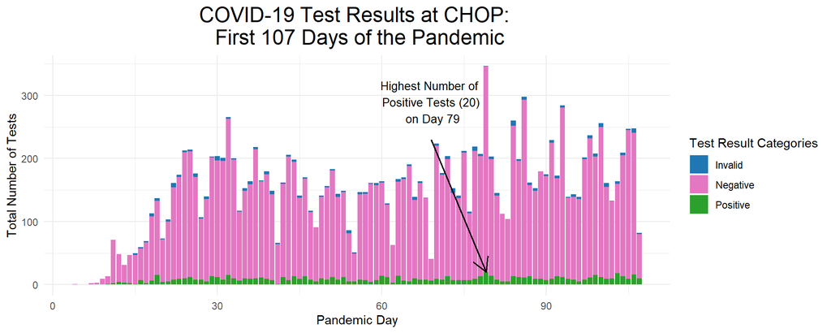

```r
plot_A <- ggplot(covid,
                 aes(x = pan_day,
                     fill = result)) +
  geom_bar(position = "stack") + # make a stacked bar plot
  scale_fill_manual(values=c("#1f77b4",
                             "#e377c2",
                             "#2ca02c")) + # change the bar plot in specific colors
  labs(title = "COVID-19 Test Results at CHOP: \n First 107 Days of the Pandemic", # Change the labels on the x-axis, y-axis and title
       x = "Pandemic Day",
       y = "Total Number of Tests") +
  guides(fill = guide_legend(title = "Test Result Categories")) + # Change the label for legend
  theme_minimal() + # remove the gray background
  theme(plot.title = element_text(hjust = 0.5, size = 18)) + # adjusting the title to be centered
  geom_segment(aes(x = 69, # draw the arrow on the plot
               y = 230,
               xend = 79,
               yend = 20),
               size = 0.7,
               arrow = arrow(length = unit(0.5, "cm"))) +
  annotate(geom = "text", # write text on the plot
           x = 69,
           y = 290,
           label = "Highest Number of \n Positive Tests (20) \n on Day 79",
           size = 3.5)

plot_A
```

# Plot B

- Use the covid_summary dataframe
- Make a bar plot and change the colors of your bar plot
- Using scale_y_continuous() change the y-axis labels to percents
- Change the labels on the x-axis, y-axis, and title
- Use theme_minimal() to remove the gray background
- Use theme() to center the title and remove the legend

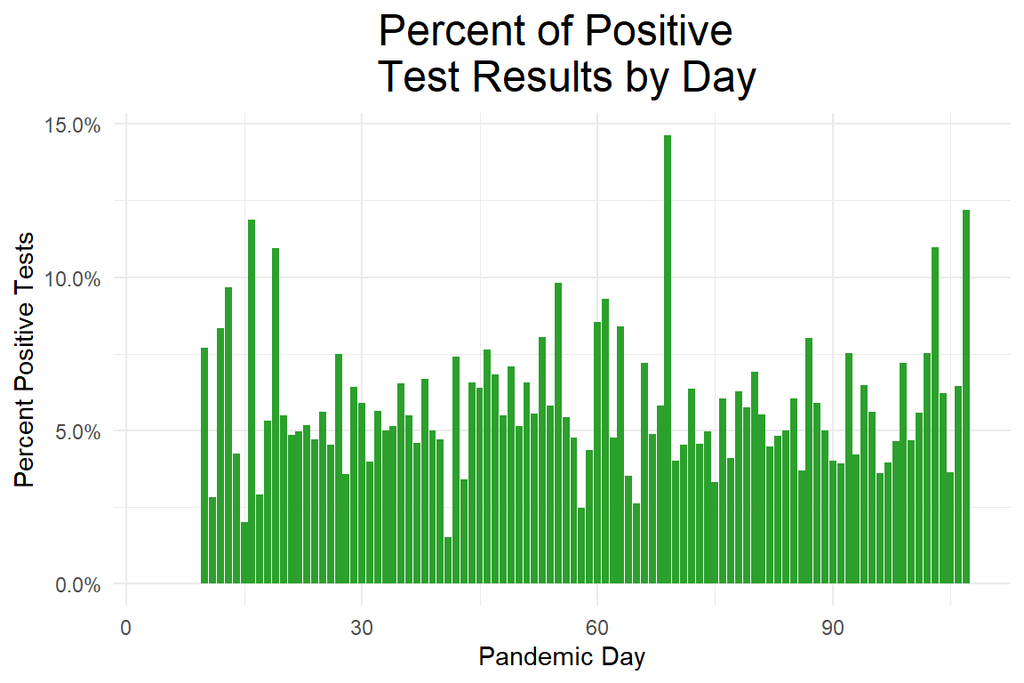

```r
plot_B <- ggplot(covid_summary,
                 aes(x = pan_day,
                     y = percent_of_positive / 100)) +
  geom_bar(stat = "identity", # make a bar plot based on percentage
           fill = "#2ca02c") + # change the color of the bar plot to a specific color
  scale_y_continuous(labels = scales::percent) + # change the y-axis labels to percents
  labs(title = "Percent of Positive \n Test Results by Day", # Change the labels on the x-axis, y-axis and title
       x = "Pandemic Day",
       y = "Percent Positive Tests") + # Change the labels on the x-axis, y-axis, and title
  theme_minimal() + # remove the gray background
  theme(plot.title = element_text(hjust = 0.5,
                                  size = 18)) # adjusting the title to be centered

plot_B
```

# Plot C

- Use the covid_ages dataframe
- Make a bar plot and change the colors of your bar plot
- Use theme_minimal() to remove the gray background
- Use theme() to center the title, remove the legend, and rotate the x-axis labels

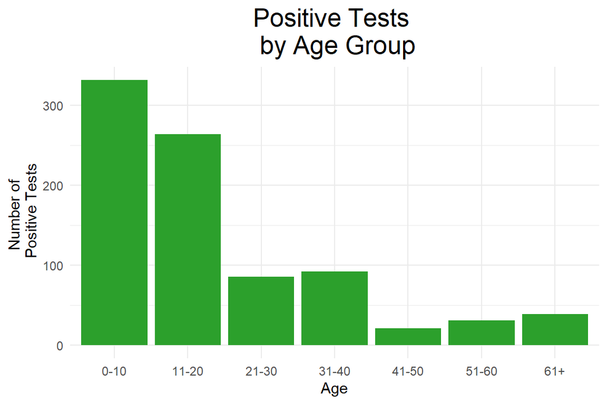

```r
plot_C <- ggplot(covid_ages,
                 aes(x = age_categories),
                 group_by(result == "Positive")) +
  geom_bar(position = "stack",
           fill = "#2ca02c") + # Make a bar plot and change the color of the bar plot to a specific color
  labs(title = "Positive Tests \n by Age Group", # Change the labels on the x-axis, y-axis and title
       x = "Age",
       y = "Number of \n Positive Tests") + # Change the labels on the x-axis, y-axis, and title
  theme_minimal() + # remove the gray background
  theme(plot.title = element_text(hjust = 0.5,
                                  size = 18)) # adjusting the title to be centered

plot_C
```

# Putting the plots together

- Use ggpubr::ggarrange to arrange the plots
- Label the plots “A”, “B”, and “C”
- Create a common legend and put this at the bottom of the plot

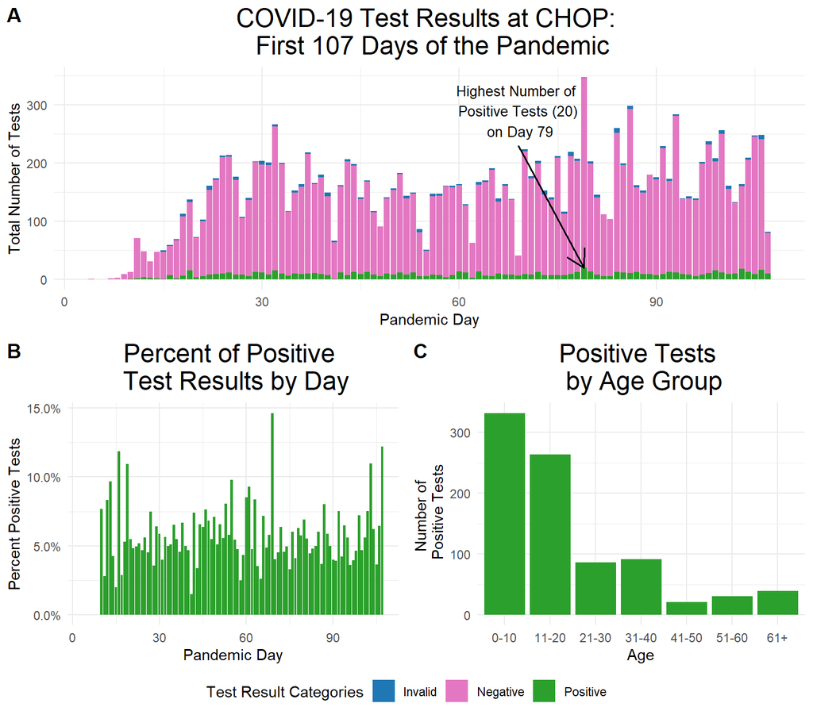

```r
# arrange the plots and label the plots “A”, “B”, and “C”
covid_combined <- ggarrange(plot_A,
                            ggarrange(plot_B,
                                      plot_C,
                                      ncol = 2,
                                      labels = c("B", "C")),
                            nrow = 2,
                            labels = "A",
                            common.legend = TRUE, # Create a common legend
                            legend = c("bottom")) # put the legend at the bottom of the plot

covid_combined
```